# Zmienność rynkowa indeksu S&P 500 i aktywów cyfrowych – analiza porównawcza

Author

Paweł Zdanowski

# 1 Wstęp i cel badania

Niniejszy projekt stanowi szczegółowe porównawnanie dynamiki zmian na tradycyjnym amerykańskim rynku kapitałowym oraz rodzącym się rynku aktywów cyfrowych w latach 2015–2023. Głównym celem pracy jest analiza zmienności (*volatility*) spółek wchodzących w skład indeksu S&P 500 oraz zestawienie tych wyników z trendami panującymi na rynku kryptowalut. Badanie opiera się na dwóch komplementarnych filarach danych: obszernym zbiorze historycznym dla ponad 500 spółek giełdowych oraz danych rynkowych dla Bitcoina, Litecoina i Ethereum, pobranych bezpośrednio z serwisu Yahoo Finance przy użyciu biblioteki `tidyquant`. Kluczowym wskaźnikiem poddanym analizie jest zmienność dzienna, zdefiniowana jako różnica między ceną najwyższą a najniższą, zewzględu na znaczące różnice w wartościach nominalnych badanych aktywów (od kilku do kilkudziesięciu tysięcy dolarów), dokonano normalizacji cen do bazy 100. Dzięki temu wykresy nie pokazują ceny w walucie, lecz dynamikę procentową zmian.Zwerifikuję osiem następujących pytań oraz hipotez badawczych:

- **Zyski: Aktywa cyfrowe vs. Rynek kapitałowy** – porównanie stóp zwrotu.
- **Zmienność dzienna** – porównanie stabilności S&P 500 i Aktywów cyfrowych
- **Wpływ pandemii COVID-19** – mechanizm katalizatora wzrostów rynkowych.
- **Konwergencja rynków**– czy Aktywa cyfrowa upodabnia się do giełdy tradycyjnej
- **Ekstremalne szoki rynkowe** – analiza częstotliwości
- **Analiza Drawdown** – głębokość spadków i czas odrabiania strat.
- **Korelacja i portfel mieszany** – czy warto łączyć akcje z kryptowalutami?
- **Lokata bankowa a rynkek giełdowy** – bezpieczeństwo kontra potencjał wzrostu.
- **Podsumowanie i wnioski** – rekomendacje dla inwestora.

# 2 Dane

**symbol-**Nazwa instrumentu finansowego

**date**-Data Notowania

**close**- Dzienna cena zamknięcia instrumentu finansowego

**volatility_usd**-Bezwzględna zmienność dzienna

**index_price**-Znormalizowana cena startująca od poziomu 100 punktów

# 3 Analiza porównawcza stóp zwrotu: Aktywa cyfrowe vs. Rynek kapitałowy

[figure not shown]

# 4 Dzienna zmienność kryptowalut jest wyższa niż zmienność indeksu S&P 500.

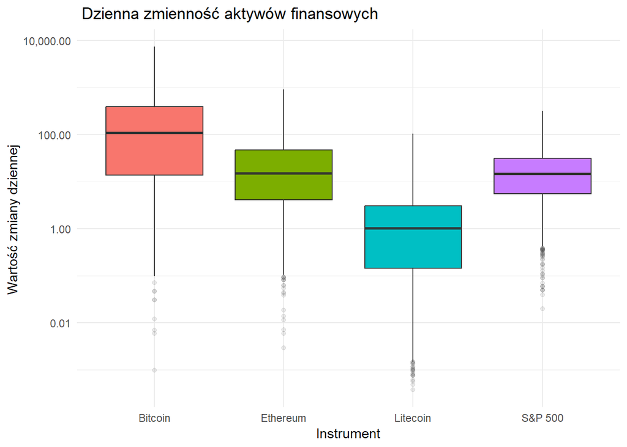

# 5 Pandemia COVID-19 jako katalizator bezprecedensowej hossy rynkowej

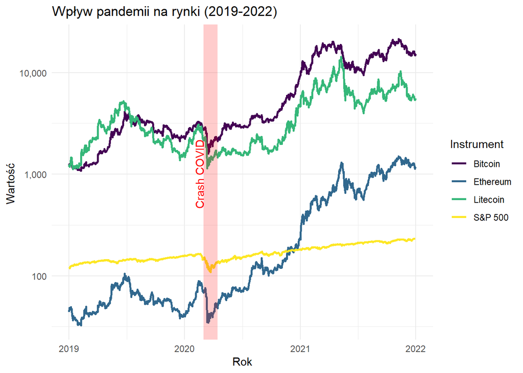

Analiza okresu 2019–2022 potwierdza, że choć marzec 2020 przyniósł gwałtowny krach na wszystkich rynkach, to późniejsza cyfryzacja i stymulacja gospodarki napędziły historyczne wzrosty. Na wykresie widać wyraźną dominację kryptowalut w fazie odbicia po pandemii. W 2015 roku Litecoin oraz Bitcoin był bardzo tani, jego wzrost do kilkuset dolarów sprawił, że początkowe 100 USD zamieniło się w tysiące dolarów zysku. Ostatecznie dane potwierdzają hipotezę: choć S&P 500 odnotował solidne odbicie i ustanowił nowe historyczne rekordy, to skala zwrotu z inwestycji w kryptowaluty w okresie popandemicznym była o rzędy wielkości wyższa.

# 6 Czy Aktywa cyfrowe coraz bardziej przypominają Rynek kapitałowy

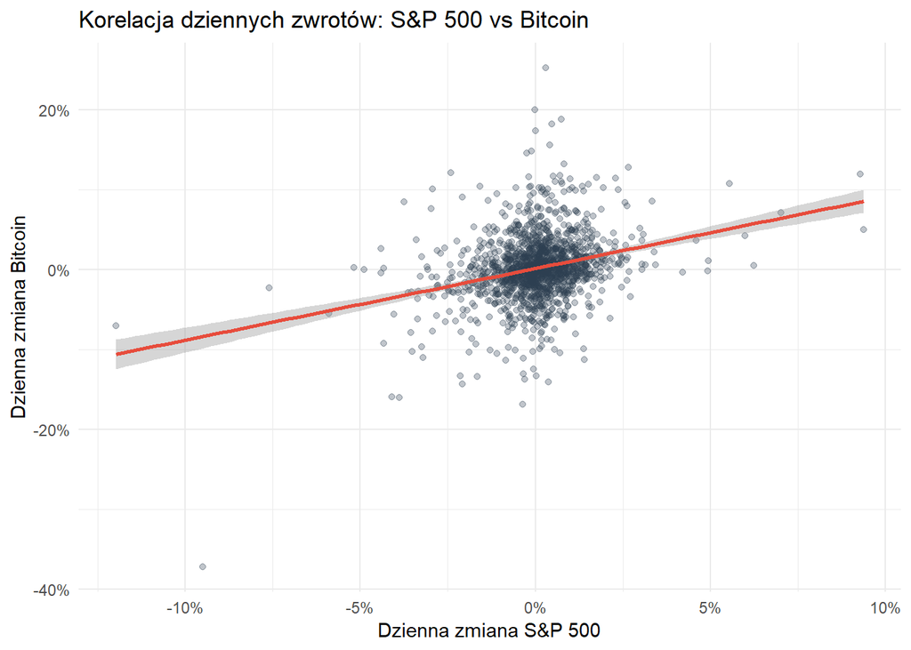

Badanym zjawiskiem w niniejszym raporcie jest wzajemna zależność rynków, zwizualizowana za pomocą wykresu rozrzutu (Scatter Plot). Oś pozioma (X) reprezentuje dzienne zwroty indeksu S&P 500.Oś pionowa (Y) w analogiczny pokazuje dzienne zwroty Bitcoina. Analiza danych potwierdza, że Bitcoin przestał być aktywem całkowicie niezależnym. Widoczna na wykresie czerwona linia trendu pnie się w górę, co jest bezpośrednim dowodem na występowanie dodatniej korelacji. Oznacza to, że oba rynki coraz częściej reagują na te same sygnały makroekonomiczne. Wizualizacja ujawnia jednak istotną asymetrię w dynamice tych ruchów Bitcoin reaguje na te same impulsy co giełda, ale z kilkukrotnie większą amplitudą. Można to zauważyć, porównując skale osi: podczas gdy punkty dla S&P 500 skupiają się głównie w wąskim przedziale +/- 3%, punkty Bitcoina są rozproszone pionowo w znacznie szerszym zakresie, sięgającym +/- 10% lub więcej. Kryptowaluty oferują tym samym wyższy potencjał zysku przy radykalnie większym ryzyku spadków.

# 7 Analiza częstotliwości występowania ekstremalnych szoków rynkowych

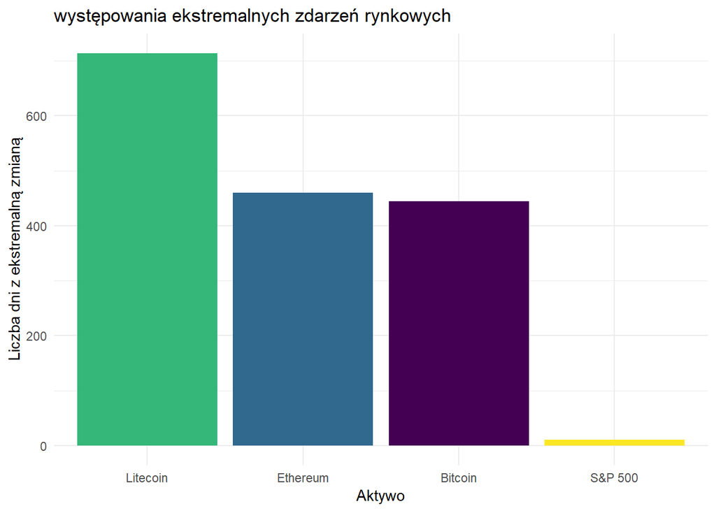

Wykres słupkowy podlicza dni od 2015 roku, w których cena danego aktywa zmieniła się o ponad 5% w ciągu jednej doby. Takie “szoki” cenowe są rzadkością na tradycyjnej giełdzie S&P 500, co potwierdza jej stabilność i czyni ją idealnym miejscem do spokojnego, długoterminowego inwestowania w modelu “kup i trzymaj”. Zupełnie inny obraz wyłania się z analizy kryptowalut – wysokie słupki dla Bitcoina, Ethereum i Litecoina pokazują, że gwałtowne skoki i spadki są tam codziennością. Ta ogromna dynamika sprawia, że kryptowaluty są doskonałym narzędziem do aktywnego tradingu, dając szansę na wypracowanie zysków w krótkim czasie, co na tradycyjnej giełdzie jest niemal niemożliwe. Podsumowując, wykres ten udowadnia, że podczas gdy giełda jest fundamentem stabilnego portfela, kryptowaluty są paliwem dla traderów szukających okazji w codziennej zmienności rynku.

# 8 **Analiza odporności na straty** – jak duże były spadki kapitału i jak długo trwało ich odrobienie.

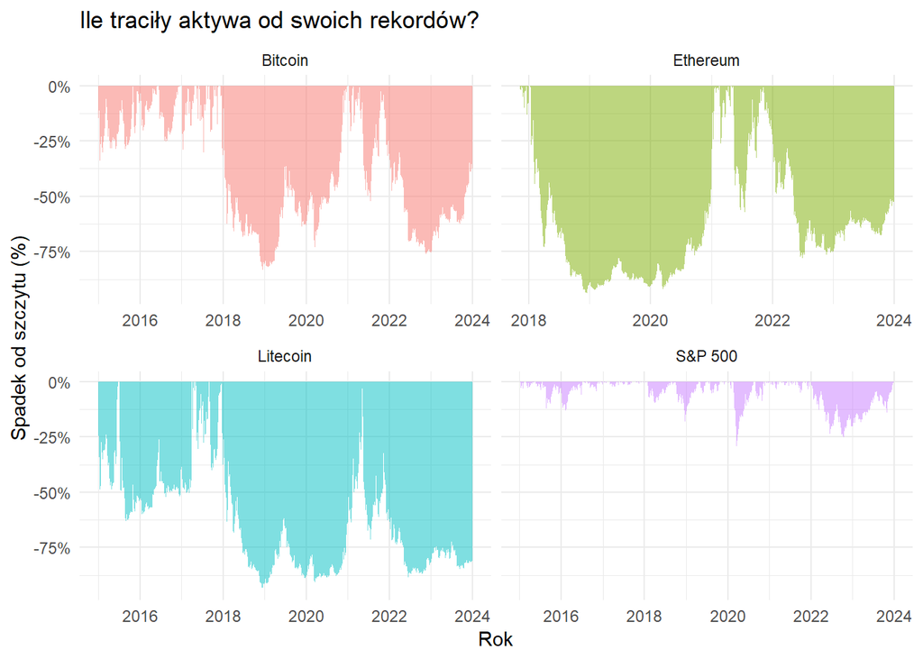

Wykres obszarowy przedstawia historię strat, pokazując, o ile procent cena każdego aktywa była niższa od swojego ostatniego rekordu w danym momencie. Analiza ta w pełni potwierdza hipotezę o ekstremalnym ryzyku kryptowalut. Podczas gdy indeks S&P 500 rzadko spada poniżej poziomu -20% i zazwyczaj relatywnie szybko odrabia straty, kryptowaluty takie jak Bitcoin czy Ethereum regularnie doświadczają spadków rzędu -50%, a nawet -80%. Wizualizacja pokazuje, że inwestorzy krypto spędzają znacznie więcej czasu „pod wodą”, czekając latami na powrót ceny do poprzedniego szczytu. Wykres ten jest najlepszym dowodem na to, że ogromne zyski z kryptowalut są okupione gigantycznym obciążeniem psychicznym – inwestor musi być gotowy na zaakceptowanie faktu, że jego portfel może stracić większość wartości i nie odrobić tego przez bardzo długi czas. S&P 500 na tym tle wygląda jak stabilny fundament, który zapewnia ochronę kapitału nawet w trudnych okresach rynkowych.

# 9 Akcje i kryptowaluty jako komplementarne elementy portfela inwestycyjnego

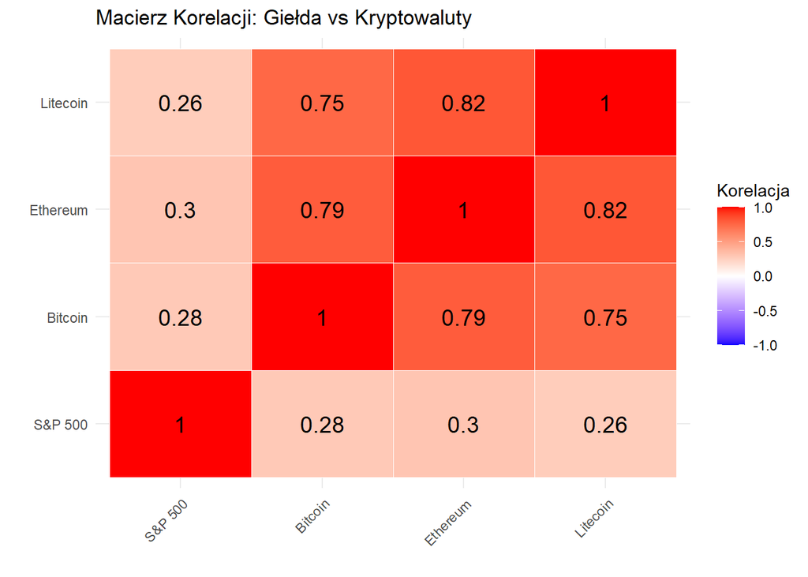

Utworzona macierz korelacji potwierdza, że kryptowaluty stanowią odrębną klasę aktywów względem tradycyjnej giełdy. Podczas gdy cyfrowe waluty są ze sobą silnie powiązane (współczynnik powyżej 0.75, ich korelacja z indeksem S&P 500 pozostaje na niskim poziomie (ok. 0.28). Dzięki temu, że S&P 500 i kryptowaluty rzadko spadają z tych samych powodów w tym samym czasie, łączny portfel będzie miał łagodniejsze wahania niż portfel składający się z samych kryptowalut.

# 10 Bezpieczeństwo lokaty bankowej a potencjał rynku giełdowego

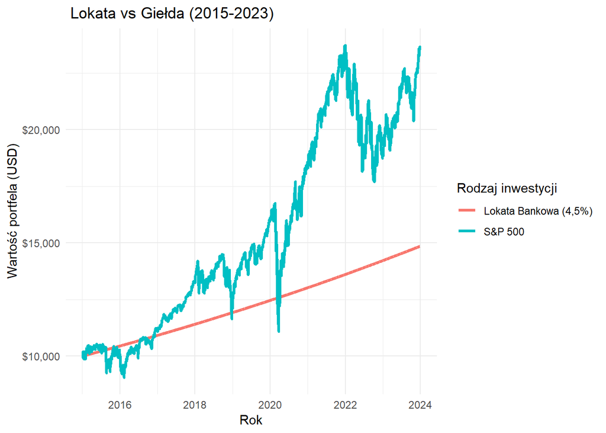

# 11 Podsumowanie

Analiza wykazała, że kryptowaluty oferują potężne zyski, lecz wymagają akceptacji drastycznej zmienności i spadków sięgających 80%. Indeks S&P 500 pozostaje fundamentem stabilności, systematycznie pokonując lokaty bankowe w długim terminie. Kluczowym wnioskiem jest niska korelacja (0,28) między tymi aktywami, co dowodzi, że giełda i krypto to odrębne światy inwestycyjne. Taka zależność sprawia, że portfel mieszany jest najbardziej efektywnym rozwiązaniem. Pozwala on na skuteczną dywersyfikację, łącząc bezpieczeństwo tradycyjnych akcji z wysoką dynamiką aktywów cyfrowych, co ostatecznie optymalizuje stosunek zysku do ryzyka.

# 12 Bibliografia

**Yahoo Finance (2024)**. *Historical Market Data: S&P 500 Index (^GSPC), Bitcoin (BTC-USD), Ethereum (ETH-USD), Litecoin (LTC-USD).* Dane historyczne za lata 2015–2023 pobrane automatycznie przy użyciu interfejsu API. Dostępne na: https://finance.yahoo.com.